# BIOL343 Coding Challenge 8: Generalized linear models and experimental design

Group # — names and student numbers in the chunk below

20 November 2026

# Group Members

```r
# Name - Queen's Student Number

# 1. Kaylee Ellwood - 20391007
# 2. Margo Kaminska - 20449041
# 3. Coralie Spakowski - 20471806
# 4. Noah Lu - 20483156
# 5. Tianyi Wang - 20386987
```

# DO THIS FIRST

Copy and paste these two lines into your R Console to install the current positpal, then **restart R** (*Session → Restart R*, or the restart button in the Console) before anything else. **Do not include them as a code chunk.**

```
install.packages("remotes")
remotes::install_url("https://quantitative.bio/downloads/positpal.tar.gz", upgrade = "never")
```

After the restart, paste this line, replacing `FILENAME.Rmd` with the name you are going to use for the .R or .Rmd file you are going to upload (rename the template first, e.g. `Group_#_CC8.Rmd`, and use that exact name):

```
positpal::start("FILENAME.Rmd")
```

Before you run it: create or open an R project folder for this challenge so that it is your working directory, then save this file in that folder under the name you will upload, and check that autosave is on (*File → Auto Save*). Closing the laptop or quitting Positron does not lose your log: when you reopen the project folder, positpal picks up where you left off and says so in the Console after your first command. **Every time you open Positron to work on this file, run the `start()` line again**, even if positpal says it picked up where you left off; it continues the same log and never erases it. See OnQ and use the positpal chatbot if you are having trouble with positpal.

# Part 1 — Import and inspect

The data file is `data/mytilus.csv`: one row per population of blue mussels (*Mytilus edulis*), with the frequency of the 94y allele at the *Lap* locus, the population’s distance east along the coast in miles, and the substrate it was collected from. The instructions describe the study. **Do not edit the file by hand.**

So far every model you have fitted has assumed normally distributed residuals. This week the response is a proportion, and you will fit a model that does not make that assumption. The last two tasks are about how data like these are collected and how an experiment could be designed to answer the same kind of question.

As in earlier challenges, the tasks tell you **what** to produce, not which function to use. The starter lines in some chunks are commented out so that the blank template knits; remove the `#` as you fill them in.

# 1 Import and plot the cline

Import the data as an object called `mytilus` and check its structure. Plot the allele frequency (y) against distance (x), coloured by substrate, with axis labels, a legend title and a clean theme.

```r
# mytilus <-
mytilus <- read.csv("data/mytilus.csv")

# check structure
dim(mytilus)
```

```
## [1] 100   3
```

```r
str(mytilus)
```

```
## 'data.frame':    100 obs. of  3 variables:
##  $ lap94y_freq: num  0.162 0.154 0.173 0.156 0.145 0.152 0.147 0.143 0.152 0.154 ...
##  $ miles_east : num  0.3 1.4 2.1 2.6 2.8 2.9 5 6.4 6.5 11.4 ...
##  $ substrate  : chr  "Cobble" "Cobble" "Cobble" "Cobble" ...
```

```r
head(mytilus)
```

```
##   lap94y_freq miles_east substrate
## 1       0.162        0.3    Cobble
## 2       0.154        1.4    Cobble
## 3       0.173        2.1    Cobble
## 4       0.156        2.6    Cobble
## 5       0.145        2.8    Cobble
## 6       0.152        2.9    Cobble
```

```r
summary(mytilus)
```

```
##   lap94y_freq       miles_east         substrate
##  Min.   :0.1300   Min.   :  0.00   Length   :100
##  1st Qu.:0.2590   1st Qu.: 18.57   N.unique :  3
##  Median :0.4035   Median : 35.55   N.blank  :  0
##  Mean   :0.4350   Mean   : 41.31   Min.nchar:  3
##  3rd Qu.:0.6035   3rd Qu.: 61.23   Max.nchar:  6
##  Max.   :0.8600   Max.   :123.10
```

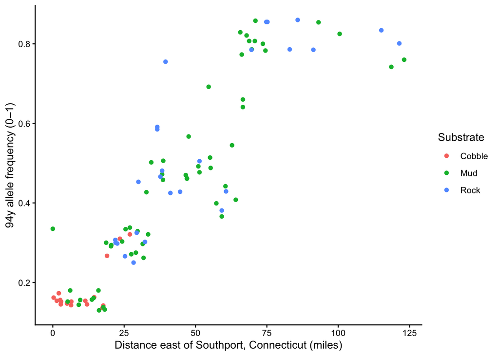

```r
# import tidyverse
library(tidyverse)

# plot allele frequency against distance, coloured by substrate
ggplot(mytilus, aes(y = lap94y_freq, x = miles_east, colour = substrate)) +
  geom_point() +
  labs(
    y = "94y allele frequency (0–1)",
    x = "Distance east of Southport, Connecticut (miles)",
    colour = "Substrate"
  ) +
  theme_classic()
```

**Question 1:** Describe the shape of the relationship between allele frequency and distance. What values can the response take, and why does that make a linear model with normal residuals a poor choice for it?

**Answer:** The relationship between allele frequency seems both positive an non-linear. Up until about 75 miles, the frequency increases gradually before leveling off at higher distances. The response variable (allele frequency) can only take values between 0 and 1 since it represents a proportion. A linear model with normal residuals is a poor choice for this since it assumes an unbounded variable, as in a variable with no fixed upper or lower limits on the values the model can predict. It also assumes constant residual variance such that the spread of the residual errors should remain roughly the same across all predicted values. Allele frequencies are bound between 0 and 1, their variance depends on the mean. A linear model could predict impossible allele frequencies below 0 or above 1.

# Part 2 — A logistic GLM

# 2 Linear model versus logistic GLM

Fit a linear model of allele frequency with distance and substrate as predictors, print the summary, and find the range of its fitted values. Then fit the same model as a generalized linear model for a proportion (binomial errors, logit link) and print the summary. Finally, refit the GLM so that it estimates the dispersion instead of assuming it, and print that summary too.

```r
# lm_mod <-
lm_mod <- lm(lap94y_freq ~ miles_east + substrate, data = mytilus)
# summary of linear model
summary(lm_mod)
```

```
##
## Call:
## lm(formula = lap94y_freq ~ miles_east + substrate, data = mytilus)
##
## Residuals:
##      Min       1Q   Median       3Q      Max
## -0.24112 -0.06784 -0.01041  0.05147  0.30475
##
## Coefficients:
##                Estimate Std. Error t value Pr(>|t|)
## (Intercept)   0.1075019  0.0271599   3.958 0.000145 ***
## miles_east    0.0069245  0.0004364  15.869  < 2e-16 ***
## substrateMud  0.0412184  0.0341773   1.206 0.230775
## substrateRock 0.0692360  0.0391737   1.767 0.080337 .
## ---
## Signif. codes:  0 '***' 0.001 '**' 0.01 '*' 0.05 '.' 0.1 ' ' 1
##
## Residual standard error: 0.1105 on 96 degrees of freedom
## Multiple R-squared:  0.795,  Adjusted R-squared:  0.7886
## F-statistic: 124.1 on 3 and 96 DF,  p-value: < 2.2e-16
```

```r
# range of fitted values
range(fitted(lm_mod))
```

```
## [1] 0.1095792 1.0173667
```

```r
# glm_mod <-
glm_mod <- glm(
  lap94y_freq ~ miles_east + substrate,
  data = mytilus,
  family = binomial(link = "logit")
)
# GLM summary
summary(glm_mod)
```

```
##
## Call:
## glm(formula = lap94y_freq ~ miles_east + substrate, family = binomial(link = "logit"),
##     data = mytilus)
##
## Coefficients:
##               Estimate Std. Error z value Pr(>|z|)
## (Intercept)   -1.89247    0.64880  -2.917  0.00354 **
## miles_east     0.03323    0.01015   3.275  0.00106 **
## substrateMud   0.23598    0.77787   0.303  0.76161
## substrateRock  0.38722    0.84936   0.456  0.64847
## ---
## Signif. codes:  0 '***' 0.001 '**' 0.01 '*' 0.05 '.' 0.1 ' ' 1
##
## (Dispersion parameter for binomial family taken to be 1)
##
##     Null deviance: 24.8737  on 99  degrees of freedom
## Residual deviance:  4.8753  on 96  degrees of freedom
## AIC: 92.383
##
## Number of Fisher Scoring iterations: 4
```

```r
# glm_mod2 <-
glm_mod2 <- glm(
  lap94y_freq ~ miles_east + substrate,
  data = mytilus,
  family = quasibinomial(link = "logit")
)
# summary of quasi-binomial GLM
summary(glm_mod2)
```

```
##
## Call:
## glm(formula = lap94y_freq ~ miles_east + substrate, family = quasibinomial(link = "logit"),
##     data = mytilus)
##
## Coefficients:
##                Estimate Std. Error t value Pr(>|t|)
## (Intercept)   -1.892473   0.148615 -12.734   <2e-16 ***
## miles_east     0.033230   0.002324  14.298   <2e-16 ***
## substrateMud   0.235981   0.178181   1.324   0.1885
## substrateRock  0.387219   0.194557   1.990   0.0494 *
## ---
## Signif. codes:  0 '***' 0.001 '**' 0.01 '*' 0.05 '.' 0.1 ' ' 1
##
## (Dispersion parameter for quasibinomial family taken to be 0.05246957)
##
##     Null deviance: 24.8737  on 99  degrees of freedom
## Residual deviance:  4.8753  on 96  degrees of freedom
## AIC: NA
##
## Number of Fisher Scoring iterations: 4
```

**Question 2:** Which predicted frequencies from the linear model are impossible? What does the warning from the binomial GLM mean? Compare the estimates and the standard errors of the two GLMs: what is the dispersion parameter of the second one, what would a value of 1 mean, and which of the two GLMs would you report?

**Answer:** The linear model produced a fitted-value range of 0.1095792 to 1.0173667. The maximum predicted frequency of 1.0173667 is greater than 1 and is impossible since allele frequencies must fall between 0 and 1.

For both GLMs, the coefficient estimates produced were identical. They do, however, differ in their standard errors with the quasi-binomial model having smaller standard errors. This is because its estimated dispersion parameter was 0.05246957, which indicates underdispersion relative to the binomial model. A dispersion parameter of 1 would indicate that dispersion matches the binomial model’s expectations. Less than 1 means less variability than expected or underdispersion. As such, I would report the quasi-binomial model because it estimates dispersion rather than assuming it is 1.

# 3 Reading the coefficients

The GLM’s estimates are on the logit (log-odds) scale. To turn a value Y on that scale into a frequency P, use

P = 1 / (1 + e^(−Y))

Using the estimates from your GLM, calculate Y and the predicted frequency for a Mud population at 10 miles and at 60 miles. Then add the fitted curve for each substrate to your plot from the first task.

```r
# Y for Mud population at 10 miles
Y10 <- -1.89247 + (0.03322954 * 10) + 0.23598134

# Y for Mud population at 60 miles
Y60 <- -1.89247 + (0.03322954 * 60) + 0.23598134

# Predicted frequency for Mud population at 10 miles
P10 <- 1 / (1 + exp(-Y10))
P10
```

```
## [1] 0.2101215
```

```r
# Predicted frequency for Mud population at 10 miles
P60 <- 1 / (1 + exp(-Y60))
P60
```

```
## [1] 0.5835306
```

```r
# Predicted
class(mytilus$substrate)
```

```
## [1] "character"
```

```r
unique(mytilus$substrate)
```

```
## [1] "Cobble" "Mud"    "Rock"
```

```r
levels(mytilus$substrate)
```

```r
mytilus$substrate <- as.factor(mytilus$substrate)

predict_data <- expand.grid(
  miles_east = seq(
    min(mytilus$miles_east),
    max(mytilus$miles_east),
    length.out = 100
  ),
  substrate = levels(mytilus$substrate)
)

predict_data
```

```
##     miles_east substrate
## 1     0.000000    Cobble
## 2     1.243434    Cobble
## 3     2.486869    Cobble
## 4     3.730303    Cobble
## 5     4.973737    Cobble
## 6     6.217172    Cobble
## 7     7.460606    Cobble
## 8     8.704040    Cobble
## 9     9.947475    Cobble
## 10   11.190909    Cobble
## 11   12.434343    Cobble
## 12   13.677778    Cobble
## 13   14.921212    Cobble
## 14   16.164646    Cobble
```

[output cut: 286 more lines]

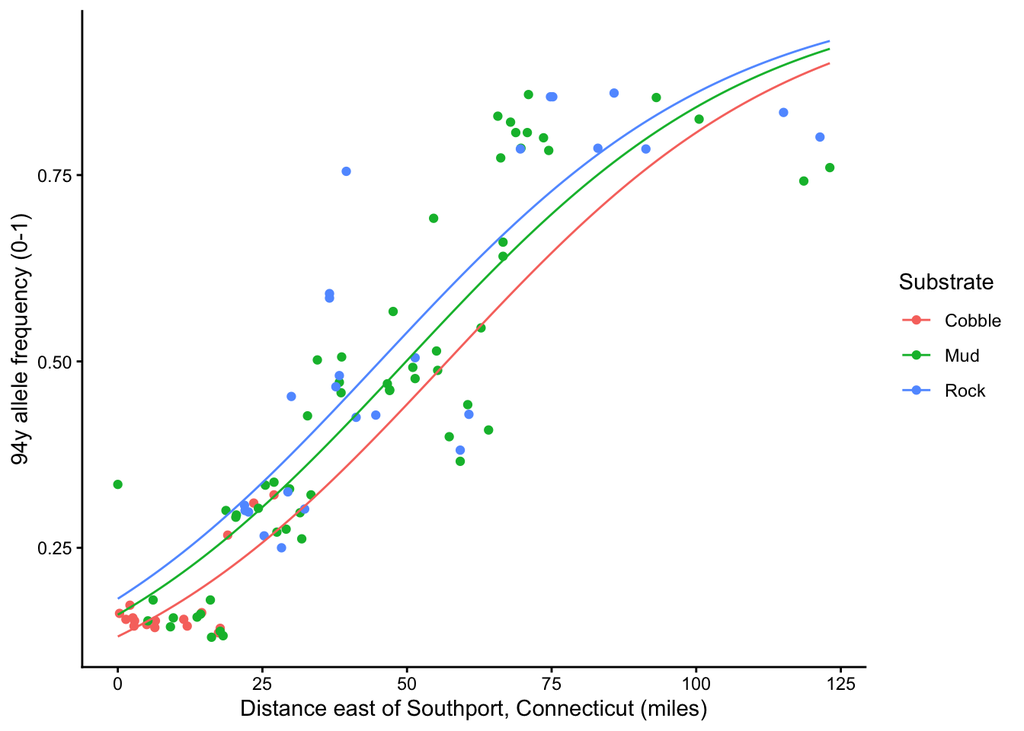

```r
predict_data$predicted <- predict(
  glm_mod2,
  newdata = predict_data,
  type = "response"
)

# Fitted curve for each substrate added to plot from first task
ggplot(mytilus, aes(y = lap94y_freq, x = miles_east, colour = substrate)) +
  geom_point() +
  labs(
    y = "94y allele frequency (0–1)",
    x = "Distance east of Southport, Connecticut (miles)",
    colour = "Substrate"
  ) +
  geom_line(
    data = predict_data,
    aes(x = miles_east, y = predicted, colour = substrate)
  ) +
  labs(
    x = "Distance east of Southport, Connecticut (miles)",
    y = "94y allele frequency (0-1)",
    colour = "Substrate"
  ) +
  theme_classic()
```

**Question 3:** Report the two predicted frequencies. On the logit scale the distance effect is a straight line; what does the estimate for distance mean on that scale, and why does a change of 50 miles raise the predicted frequency by a different amount in the middle of the cline than at its ends?

**Answer:** The predicted frequencies for for Mud population at 10 and 60 miles were 0.2101215 and 0.5835306 respectively. The quasi-binomial GLM’s distance estimate is 0.033230, meaning that for every mile east, the 94y allele log-odds increase by 0.033230. This indicates positive relationship between distance and allele frequency. However, the relationship between log-odds and alle frequency is non-linear. The frequency changes faster in the middle of the cline where predicted frequencies are closer to 0.5. The changes are slower at either end where frequencies approach 0 or 1. This is why the same 50-mile increase raises the predicted frequency by a different amount in the middle of the cline than at its ends.

# Part 3 — Quality checks

# 4 Check the model and the data

Make the standard diagnostic plots for your GLM, including the one that shows influential points. Look back at your plot of the data and at the diagnostic plots, and identify any populations that look problematic. Find their rows, and refit the model without them so you can see how much they matter.

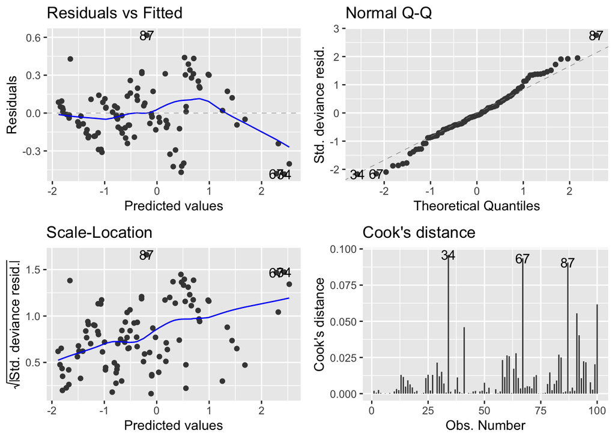

```r
# Diagnostic plots for GLM
library(ggfortify)
autoplot(glm_mod2, which = 1:4, data = mytilus)
```

```r
# Identify problematic populations/rows
cooks <- cooks.distance(glm_mod2)
problem_rows <- which(cooks > 4 / nrow(mytilus))
mytilus[problem_rows, ]
```

```
##     lap94y_freq miles_east substrate
## 34        0.760      123.1       Mud
## 41        0.335        0.0       Mud
## 67        0.742      118.6       Mud
## 87        0.755       39.5      Rock
## 91        0.381       59.2      Rock
## 92        0.429       60.7      Rock
## 100       0.801      121.4      Rock
```

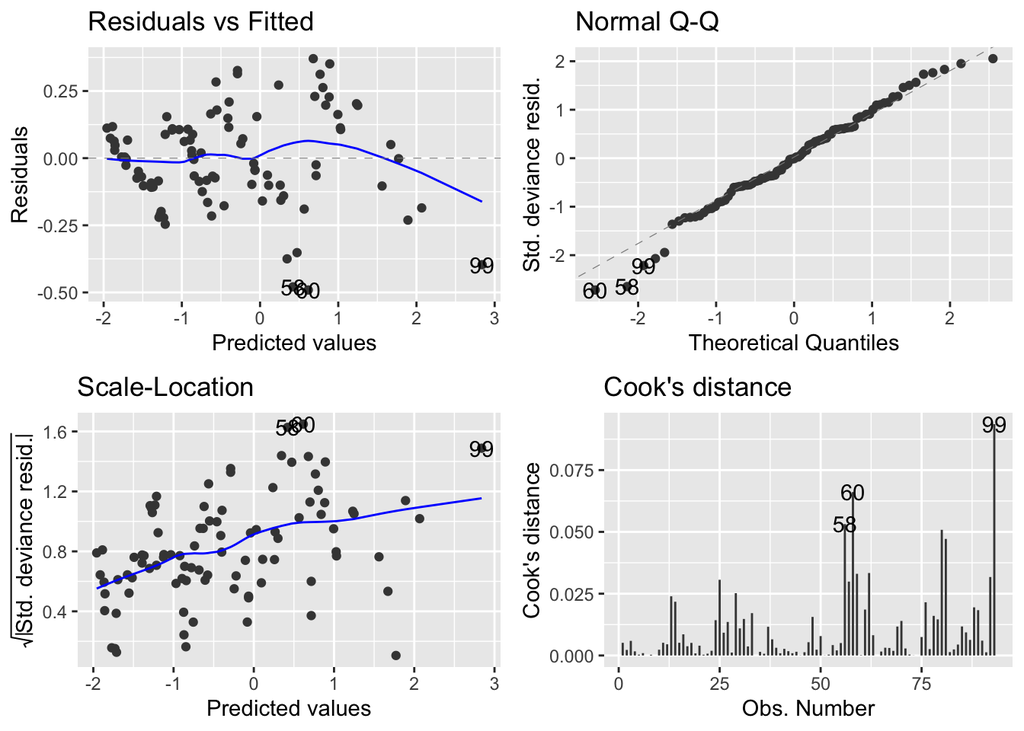

```r
# Remove problem rows
mytilus_clean <- mytilus[-problem_rows, ]
glm_mod2_clean <- glm(
  lap94y_freq ~ miles_east + substrate,
  family = quasibinomial,
  data = mytilus_clean
)

# Refit model without the problematic rows
autoplot(glm_mod2_clean, which = 1:4, data = mytilus_clean)
```

```r
# comparing summaries
summary(glm_mod2)
```

```
##
## Call:
## glm(formula = lap94y_freq ~ miles_east + substrate, family = quasibinomial(link = "logit"),
##     data = mytilus)
##
## Coefficients:
##                Estimate Std. Error t value Pr(>|t|)
## (Intercept)   -1.892473   0.148615 -12.734   <2e-16 ***
## miles_east     0.033230   0.002324  14.298   <2e-16 ***
## substrateMud   0.235981   0.178181   1.324   0.1885
## substrateRock  0.387219   0.194557   1.990   0.0494 *
## ---
## Signif. codes:  0 '***' 0.001 '**' 0.01 '*' 0.05 '.' 0.1 ' ' 1
##
## (Dispersion parameter for quasibinomial family taken to be 0.05246957)
##
##     Null deviance: 24.8737  on 99  degrees of freedom
## Residual deviance:  4.8753  on 96  degrees of freedom
## AIC: NA
##
## Number of Fisher Scoring iterations: 4
```

```r
summary(glm_mod2_clean)
```

```
##
## Call:
## glm(formula = lap94y_freq ~ miles_east + substrate, family = quasibinomial,
##     data = mytilus_clean)
##
## Coefficients:
##                Estimate Std. Error t value Pr(>|t|)
## (Intercept)   -1.969976   0.120265 -16.380   <2e-16 ***
## miles_east     0.039846   0.002173  18.338   <2e-16 ***
## substrateMud   0.032224   0.147823   0.218    0.828
## substrateRock  0.223031   0.161862   1.378    0.172
## ---
## Signif. codes:  0 '***' 0.001 '**' 0.01 '*' 0.05 '.' 0.1 ' ' 1
##
## (Dispersion parameter for quasibinomial family taken to be 0.03371595)
##
##     Null deviance: 22.950  on 92  degrees of freedom
## Residual deviance:  2.966  on 89  degrees of freedom
## AIC: NA
##
## Number of Fisher Scoring iterations: 4
```

**Question 4:** Do the diagnostic plots show a problem with the model? If some populations look problematic, what happens to your model if you remove them? How could you deal with these problems if this was your project?

**Answer:** The diagnostic plots show 7 populations that are potentially problematic. Cook’s distance test was run using a threshold of 4/n. Rows 34, 41, 67, 87, 91, 92, and 100 were flagged. After removing these populations and refitting the model, the substrate coefficients decreased. Mud and Rock p-values increased. Mud (p = 0.828) remained statistically insignificant, while Rock (p = 0.172) also became statistically insignificant. The distance coefficient increased a bit but maintained a high statistical significance (p<2e-16). This suggests that the relationship between distance east and allele frequency is relatively consistent. However, following the removal of the problematic populations, we see that it is possible Mud and Rock substrates were highly sensitive to the populations that are no longer in the data set. If this was my project, I would revisit these 7 populations and investigate potential errors that could have come about for instance in sampling, in recording, chance variation, or from specific environmental conditions. Some things could be corrected immediately such as a mistake in data entry. If an error could not be corrected, I would remove that data from my models. However, before deciding whether to completely exclude the influential populations, I would want to consider approaches or methodologies that might be more appropriate since I want the final conclusions to accurately represent the biological patterns in the data.

# Part 4 — Experimental design

# 5 Is it the substrate or the place?

Summarise the distance of the populations on each substrate (number of populations, smallest, mean and largest distance). Then fit your GLM with substrate as the only predictor, print the summary, and compare its substrate estimates with those from the model that also includes distance.

```r
# Summarise distance by substrate
mytilus %>%
  group_by(substrate) %>%
  summarise(
    n = n(),
    smallest_distance = min(miles_east),
    mean_distance = mean(miles_east),
    largest_distance = max(miles_east)
  )
```

```
## # A tibble: 3 × 5
##   substrate     n smallest_distance mean_distance largest_distance
##   <fct>     <int>             <dbl>         <dbl>            <dbl>
## 1 Cobble       17               0.3          10.1              27
## 2 Mud          57               0            45.3             123.
## 3 Rock         26              21.9          52.8             121.
```

```r
# GLM with substrate as only predictor
glm_sub <- glm(
  lap94y_freq ~ substrate,
  family = quasibinomial,
  data = mytilus
)
summary(glm_sub)
```

```
##
## Call:
## glm(formula = lap94y_freq ~ substrate, family = quasibinomial,
##     data = mytilus)
##
## Coefficients:
##               Estimate Std. Error t value Pr(>|t|)
## (Intercept)    -1.5316     0.2675  -5.726 1.15e-07 ***
## substrateMud    1.3821     0.2900   4.766 6.60e-06 ***
## substrateRock   1.7024     0.3148   5.408 4.58e-07 ***
## ---
## Signif. codes:  0 '***' 0.001 '**' 0.01 '*' 0.05 '.' 0.1 ' ' 1
##
## (Dispersion parameter for quasibinomial family taken to be 0.1777965)
##
##     Null deviance: 24.874  on 99  degrees of freedom
## Residual deviance: 18.404  on 97  degrees of freedom
## AIC: NA
##
## Number of Fisher Scoring iterations: 4
```

```r
# Compare with the model including geographic distance
summary(glm_mod2)
```

```
##
## Call:
## glm(formula = lap94y_freq ~ miles_east + substrate, family = quasibinomial(link = "logit"),
##     data = mytilus)
##
## Coefficients:
##                Estimate Std. Error t value Pr(>|t|)
## (Intercept)   -1.892473   0.148615 -12.734   <2e-16 ***
## miles_east     0.033230   0.002324  14.298   <2e-16 ***
## substrateMud   0.235981   0.178181   1.324   0.1885
## substrateRock  0.387219   0.194557   1.990   0.0494 *
## ---
## Signif. codes:  0 '***' 0.001 '**' 0.01 '*' 0.05 '.' 0.1 ' ' 1
##
## (Dispersion parameter for quasibinomial family taken to be 0.05246957)
##
##     Null deviance: 24.8737  on 99  degrees of freedom
## Residual deviance:  4.8753  on 96  degrees of freedom
## AIC: NA
##
## Number of Fisher Scoring iterations: 4
```

**Question 5:** Why are the substrate effects so much larger when distance is left out of the model? Is this study an experiment or an observational survey, and which element of a designed experiment is missing that would let you separate the effect of substrate from the effect of place? Briefly describe an experiment that could test whether substrate itself affects 94y frequency (or survival of 94y carriers).

**Answer:** Substrate effects are so much larger when distance is left out of the model because substrate and geographic location are likely confounded. As you move east, salinity increaces, and allele frequency also increases. As a result, some of the apparent substrate effect may actually be explained by geographic location. This study is an observational survey because mussels were collected from naturally occurring populations rather than randomly assigned to treatments. Random assignment would be the element of a designed experiment that is missing which would let me separate the effect of substrate from the effect of place. To test the effect of substrate, I would collect mussels from several populations and randomly assign them to replicated environments containing Cobble, Mud, or Rock. I would keep salinity and other environmental conditions constant and measure allele frequency over time to determine whether substrate itself has an effect.

# 6 Laying out a field trial

A plant breeder wants to compare grain yield of hybrid and inbred corn. The trial has **5 blocks** (areas of a field) and **4 seed families**: 2 hybrid and 2 inbred. Every family is planted in every block, with **2 plants per family per block**, and the plants are placed at random within each block.

Draw a diagram showing the experimental design. You don’t have to draw out every single plant, but make sure the design is clear, and you have labelled blocks and individuals, and which individuals belong to the same seed family (hint: using shapes or colours with a legend can help here). Draw it by hand or with any drawing tool, save it as an image (e.g. `design.png`) in your project folder, and show it in this document by adding a line `![Experimental design](design.png)` below this paragraph (outside any code chunk).

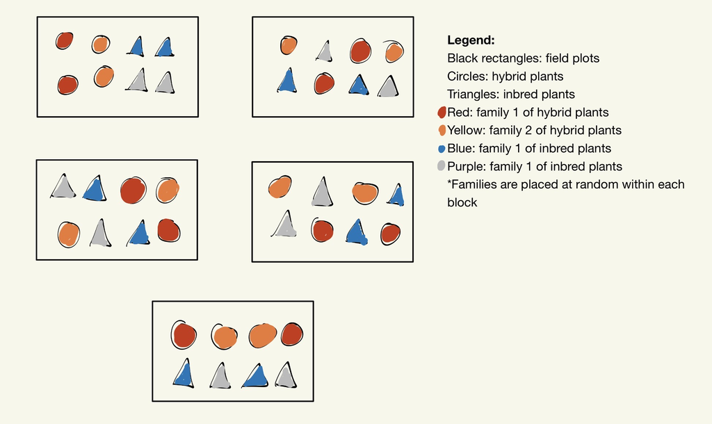

Experimental design

**Question 6:** What is the replicate for the comparison of hybrid and inbred corn: a plant or a family? How many independent replicates of each line does the trial have, and what would be wrong with analysing the 40 plants as independent replicates? Why is every family planted in every block, with positions randomized within blocks, rather than (say) all hybrids in blocks 1–2 and all inbreds in blocks 3–5?

**Answer:** The replicate comparison is a family since the comparison is between genetic lines and not individual plants. The trial has 2 independent genetic replicates per line type (2 hybrid families and 2 inbred families). Analysing the 40 plants as independent replicates would be wrong since plants from the same family are not actually independent. This would be pseudoreplication. This would artificially inflate the degrees of freedom which would make standard errors appear much smaller than in reality. This may also increase false positives as it is much more likely to claim a statistically significant difference between hybrids and inbreds when none actually exists. Additionally, this may result in confounding family variation with line-type variation. Every family is planted in every block, with positions randomized within blocks to account for the environmental differences in the different fields (e.g. soil or sunlight). This in turn lowers bias since we are looking at the impact of genetic mutation, rather than the impact of the location.

# DO THIS LAST

When your document is finished, knit it, open the `.html` in a web browser and **print it to PDF** (*File → Print → Save as PDF*; name it `Group_#_CC8.pdf`). Then copy and paste this into the R Console to stop positpal and create your coding log. **Do not include it as a code chunk.**

```
positpal::stop_capture()
positpal::export_capture()
```

`export_capture()` prints the name and location of the `my-capture-YYYYMMDD-HHMMSS.zip` it creates beside this file. **Each group member** uploads their own `.zip` to the **“CC8 — Coding Log (individual)”** dropbox on OnQ; the group’s `.Rmd`, `.html` and **`.pdf`** (OnQ shows uploaded HTML as source code, so the PDF is what gets graded; the `.html` is a back-up) go to your section’s **TUT02-CC8** or **TUT03-CC8** folder. Submissions without the log are incomplete. If `export_capture()` fails, zip the `.capture` folder yourself and upload that instead.